# Cost per Download for Big 5 Providers

UVA StatLab/RDS

Adding in information about the cost to UVA for each of the Big 5 providers in 2017, we can calculate the cost per download, or the package cost in dollars in 2017 divided by the number of downloads in 2017. We do this for both all 2017 downloads (JR1) and current year downloads in 2017 (JR5). The cost-per-use estimates are provided to the right of the point; the number of relevant downloads are provided below the the point.

### 3a. Cost per Download, all 2017 downloads

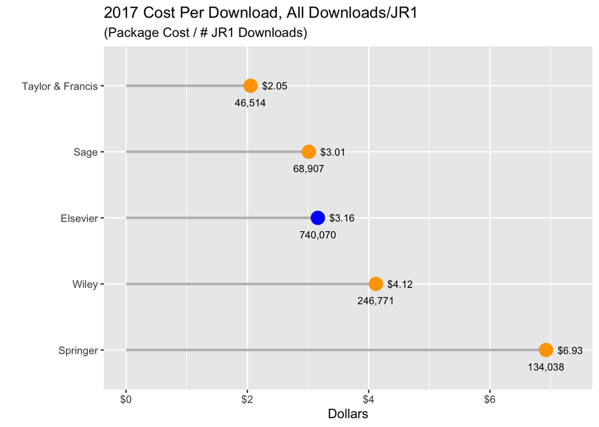

This calculation is frequently cited by vendors as “cost-per-use.” By this metric, Elsevier has a cost-per-use of $3.16. However, this may be misleading insofar as it includes back year content for which we have already purchased perpetual access.

Note, also, that downloads of articles in Elsevier titles far exceeds downloads in the other big packages.

### 3b. Cost per Download, current year 2017 downloads

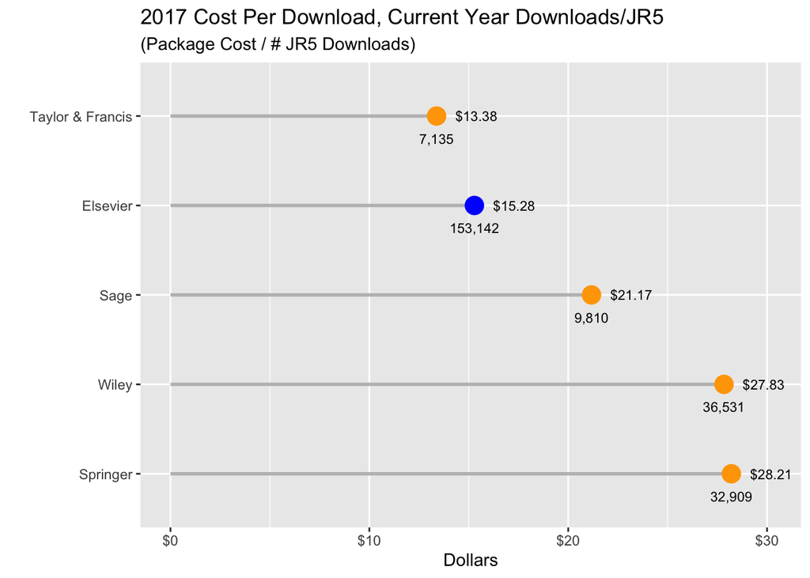

Using only current-year downloads generates a higher cost-per-use estimate, of course. This value may be more meaningful, however, as it reflects only the use of new content added by the current year’s subscription.

## Elsevier Freedom versus Elsevier Subscribed

The figures above are repeated below but with Elsevier journals disaggregated into the Freedom collection and Subscribed collection.

### 3c. Cost per Download, all 2017 downloads

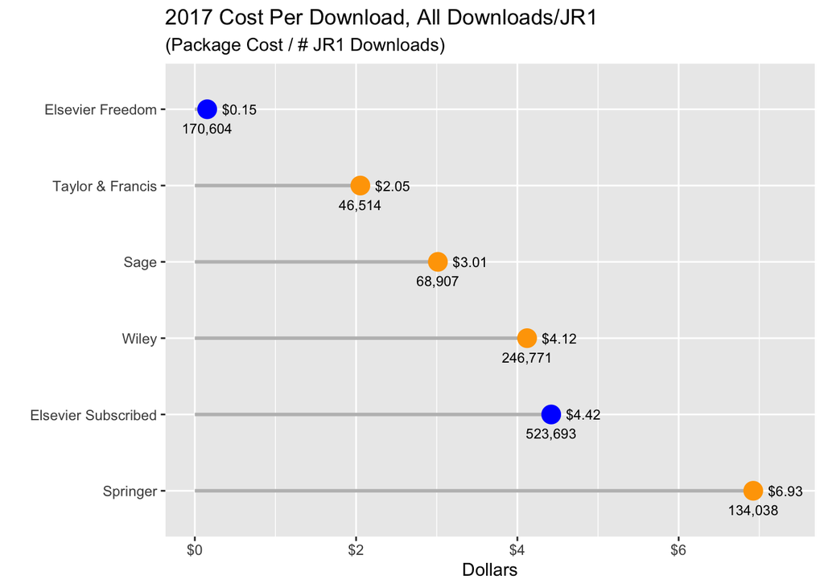

Because 99% of the Elsevier package cost is for the Subscribed Collection, the cost-per-use within the Freedom Collection is trivial. Removing use of the Freedom Collection from the cost calculation increases the apparent cost-per-use for the Subscribed Collection. Downloads of articles within the Freedom Collection, however, represent a fairly high number of downlaods relative to the remaining big deal packages.

### 3d. Cost per Download, current year 2017 downloads

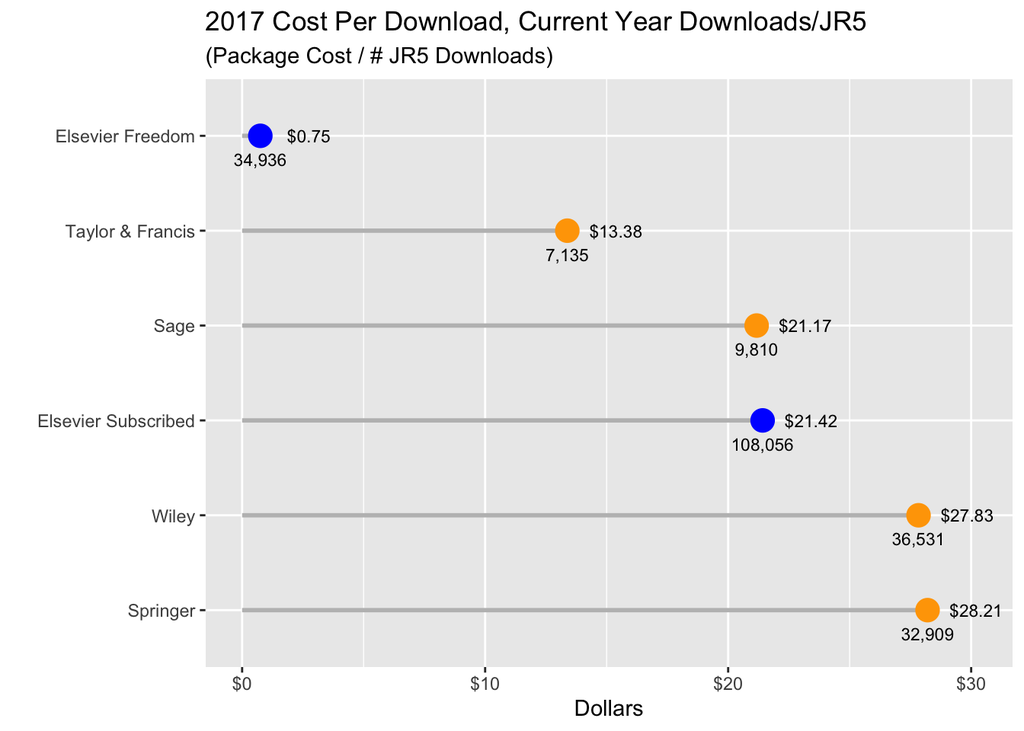